# DeepBlueR - DeepBlue Epigenomic Data Server - R package

Felipe Albrecht, Markus List

2017-03-19

[figure not shown]

# Introduction

The DeepBlue Epigenomic Data Server is an online application that allows researchers to access data from various epigenomic mapping consortia such as DEEP, BLUEPRINT, ENCODE, or ROADMAP. DeepBlue can be accessed through a [web interface](http://deepblue.mpi-inf.mpg.de) or programmatically via its [API](http://deepblue.mpi-inf.mpg.de/api.php). The usage of the API is documented with [examples](http://deepblue.mpi-inf.mpg.de/examples.php), [use cases](http://deepblue.mpi-inf.mpg.de/use_cases.php), and a [user manual](http://deepblue.mpi-inf.mpg.de/manual). While the description of the API is language agnostic, the examples and use cases shown online are focused on the python language. However, the R package presented here also enables access to the DeepBlue API directly within the R statistical environment and provides convenient functionality for triggering operations on the DeepBlue server as well as for data retrievel using R functions. In the following, we give a brief introduction to the package and subsequently show how python examples from the online documentation can be reproduced with it.

## What is DeepBlue ?

A wealth of epigenomic data has been collected over the past decade by large epigenomic mapping consortia. Event though most of these data are publicly available, the task of identifiying, downloading and processing data from various experiments is challenging. Recognizing that these tedious steps need to be tackled programmatically, we developed the DeepBlue epigenomic data server. Epigenome data from the different epigenome mapping consortia are accessible with standardized metadata. An experiment is the most important entity in DeepBlue and typically encompasses a single file (usually a bed or wig file) with a set of mandatory metadata: name, genome assembly, epigenetic mark, biosource, sample, technique, and project. For the sake of organization, all metadata fields are part of controlled vocabularies, some of which are imported from ontologies (CL, EFO, and UBERON, to name a few). DeepBlue also contains annotations, i.e. auxiliary data that is helpful in epigenomic analysis, such as, for example, CpG Islands, promoter regions, and genes. DeepBlue provides different types of commands, such as listing and searching commands as well as commands for data retrieval. A typical work-flow for the latter is to select, filter, transform, and finally download the selected data. For a more thorough description of DeepBlue we refer to the [DeepBlue publication](http://dx.doi.org/10.1093/nar/gkw211) in the 2016 NAR webserver issue. If you find DeepBlue useful and use it in your project consider citing this paper.

Important note: With the exception of data aggregation tasks, DeepBlue does not alter the imported data, i.e. it remains exactly as provided by the epigenome mapping consortia.

# Getting started

## Installation

Installation of DeepBlueR and its companion packages can be performed using the Bioconductor installer:

```r
source("https://bioconductor.org/biocLite.R")
biocLite("DeepBlueR")
```

The package name is `DeepBlueR` and it can be loaded via:

```r
library(DeepBlueR)
```

You can test your installation and connectivity by saying hello to the DeepBlue server:

```r
deepblue_info("me")
```

## Overview of DeepBlue commands

DeepBlue provides a comprehensive programmatic interface for finding, selecting, filtering, summarizing and downloading annotated genomic region sets. Downloaded region sets are stored using the GenomicRanges R package, which allows for downloaded region sets to be further processed, visualized and analyzed with existing R packages such as LOLA or GViz.

A list of all commands available by DeepBlue is provided in its [API page](http://deepblue.mpi-inf.mpg.de/api.php). The vast majority of these commands is also available through this R package and can be listed as follows:

`help(package="DeepBlueR")`

In the following we listed the most frequently used DeepBlue commands. The full list of commands is available [here](http://deepblue.mpi-inf.mpg.de/api.php). Note that each command in the following two tables has the prefix ’deepblue_*’, e.g. deepblue_select_genes.

| Category | Command | Description |
| --- | --- | --- |
| Information | info | Information about an entity |
| List and search | list_genomes | List registered genomes |
|  | list_biosources | List registered biosources |
|  | list_samples | List registered samples |
|  | list_epigenetic marks | List registered epigenetic marks |
|  | list_experiments | List available experiments |
|  | list_annotations | List available annotations |
|  | search | Perform a full-text search |
| Selection | select_regions | Select regions from experiments |
|  | select_experiments | Select regions from experiments |
|  | select_annotations | Select regions from annotations |
|  | select_genes | Select genes as regions |
|  | select_expressions | Select expression data |
|  | tiling_regions | Generate tiling regions |
|  | input_regions | Upload and use a small region-set |
| Operation | aggregate | Aggregate and summarize regions |
|  | filter_regions | Filter regions by theirs attributes |
|  | flank | Generate flanking regions |
|  | intersection | Filter for intersecting regions |
|  | overlap | Filter for regions overlapping by at least a specific size |
|  | merge_queries | Merge two regions set |
| Result | count_regions | Count selected regions |
|  | score_matrix | Request a score matrix |
|  | get_regions | Request the selected regions |
|  | binning | Bin results according to counts |
| Request | get_request data | Obtain the requested data |

In addition, this package provides a set of convenience functions not part of the DeepBlue API, such as:

| Category | Command | Description |
| --- | --- | --- |
| Request | batch_export_results | Download the results for a list of requests |
|  | download_request_data | Download and convert the requested data (blocking) |
|  | export_meta_data | Export metadata to a tab delimited file |
|  | export_tab | Export any result as tab delimited file |
|  | export_bed | Export GenomicRanges results as BED file |

# DeepBlue usage examples

In the following we give a number of increasingly complex examples illustrating what DeepBlue can achieve in your epigenomic data analysis work-flow. We go beyond the online description of these examples by showing how the retrieved information can be further used in R.

One of the first tasks in DeepBlue is finding the data of interest. This can be achieved in three ways:

- Using full-text search with the `deepblue_search` command
- Listing the available data with the `deepblue_list_{experiments, annotations, ...}` commands
- Using the companion [DeepBlue web interface](http://deepblue.mpi-inf.mpg.de/) site for listing the data

### Full-text search

```r
# We are selecting the experiments with terms 'H3k27AC', 'blood', and
# 'peak' in the metadata.
experiments_found = deepblue_search(
    keyword="'H3k27AC' 'blood' 'peak'", type="experiments")

custom_table = do.call("rbind", apply(experiments_found, 1, function(experiment){
  experiment_id = experiment[1]
  # Obtain the information about the experiment_id
  info = deepblue_info(experiment_id)

  # Print the experiment name, project, biosource, and epigenetic mark.
  with(info, { data.frame(name = name, project = project,
    biosource = sample_info$biosource_name, epigenetic_mark = epigenetic_mark)
      })
}))
  head(custom_table)
```

```
##                          name             project biosource
## 1 E038-H3K27ac.narrowPeak.bed Roadmap Epigenomics     BLOOD
## 2 E047-H3K27ac.narrowPeak.bed Roadmap Epigenomics     BLOOD
## 3 E048-H3K27ac.narrowPeak.bed Roadmap Epigenomics     BLOOD
## 4 E037-H3K27ac.narrowPeak.bed Roadmap Epigenomics     BLOOD
## 5 E045-H3K27ac.narrowPeak.bed Roadmap Epigenomics     BLOOD
## 6 E040-H3K27ac.narrowPeak.bed Roadmap Epigenomics     BLOOD
##   epigenetic_mark
## 1         H3K27ac
## 2         H3K27ac
## 3         H3K27ac
## 4         H3K27ac
## 5         H3K27ac
## 6         H3K27ac
```

### Listing experiments

We use the `deepblue_list_experiments` command to list all experiments with the corresponding values in their metadata.

```r
experiments = deepblue_list_experiments(type="peaks", epigenetic_mark="H3K4me3",
    biosource=c("inflammatory macrophage", "macrophage"),
    project="BLUEPRINT Epigenome")
```

### Accessing the extra-metadata

The extra-metadata is important because it contains information that is not stored in the mandatory metadata fields. We use the `deepblue_info` command to access an experiment’s metadata- and extra-metadata fields. The following example prints the `file_url` attribute that is contained in the data imported from the ENCODE project.

```r
info = deepblue_info("e30000")
print(info$extra_metadata$file_url)
```

```
## [1] "https://www.encodeproject.org/files/ENCFF001YBB/"
```

### Select epigenomic data

We use the `deepblue_select_experiments` command to select all genomic regions from the two informed experiments. We use the `deepblue_count_regions` command with the `query_id` value returned by the `deepblue_select_experiments` command.

The `deepblue_count_regions` command is executed asynchronously. This means that the user receives a `request_id` and should check the status of this request. In contrast to the command `deepblue_get_request_data`, the DeepBlueR package-specific command `deepblue_download_request_data` will wait for the processing to finish, before downloading the data. Moreover, this command will convert any regions to a GRanges object.

```r
query_id = deepblue_select_experiments(
    experiment_name=c("BL-2_c01.ERX297416.H3K27ac.bwa.GRCh38.20150527.bed",
        "S008SGH1.ERX406923.H3K27ac.bwa.GRCh38.20150728.bed"))
# Count how many regions where selected
request_id = deepblue_count_regions(query_id=query_id)
# Download the request data as soon as processing is finished
requested_data = deepblue_download_request_data(request_id=request_id)
print(paste("The selected experiments have", requested_data, "regions."))
```

```
## [1] "The selected experiments have 115347 regions."
```

### Output with selected columns

We use the `deepblue_select_experiments` command to select genomic regions from the experiments that are in chromosome 1, position 0 to 50,000,000.

We then use the `deepblue_get_regions` command with the `query_id` value returned by the `deepblue_select_experiments` command to request the regions with the selected columns. Selecting the columns `@NAME` and `@BIOSOURCE` represent the experiment name and the experiment biosource.

The `deepblue_get_regions` command is executed asynchronously. This means that the user receives a `request_id` to be able to check for the status of this request. In contrast to the command `deepblue_get_request_data`, the DeepBlueR package-specific command `deepblue_download_request_data` will wait for the processing to finish, before downloading the data. Moreover, this command will convert any regions to a GRanges object.

```r
query_id = deepblue_select_experiments (
    experiment_name = c("BL-2_c01.ERX297416.H3K27ac.bwa.GRCh38.20150527.bed",
        "S008SGH1.ERX406923.H3K27ac.bwa.GRCh38.20150728.bed"),
        chromosome="chr1", start=0, end=50000000)

# Retrieve the experiments data (The @NAME meta-column is used to include the
# experiment name and @BIOSOURCE for experiment's biosource
request_id = deepblue_get_regions(query_id=query_id,
    output_format="CHROMOSOME,START,END,SIGNAL_VALUE,PEAK,@NAME,@BIOSOURCE")
regions = deepblue_download_request_data(request_id=request_id)
regions
```

```
## GRanges object with 3783 ranges and 4 metadata columns:
##          seqnames               ranges strand | SIGNAL_VALUE      PEAK
##             <Rle>            <IRanges>  <Rle> |  <character> <integer>
##      [1]     chr1     [270668, 270987]      * |       6.5758        39
##      [2]     chr1     [271277, 271468]      * |       6.2148       136
##      [3]     chr1     [273768, 274209]      * |      14.1567       164
##      [4]     chr1     [778377, 778676]      * |       8.0198       154
##      [5]     chr1     [778409, 778678]      * |       4.5767       123
##      ...      ...                  ...    ... .          ...       ...
##   [3779]     chr1 [47437420, 47437621]      * |       3.7686       147
##   [3780]     chr1 [47437751, 47438038]      * |       9.6553       149
##   [3781]     chr1 [48245368, 48245867]      * |       4.7708       346
##   [3782]     chr1 [48542755, 48543280]      * |       7.3002       152
##   [3783]     chr1 [48793649, 48793986]      * |       5.1974       108
##                                                       @NAME   @BIOSOURCE
##                                                 <character>  <character>
##      [1] S008SGH1.ERX406923.H3K27ac.bwa.GRCh38.20150728.bed myeloid cell
##      [2] S008SGH1.ERX406923.H3K27ac.bwa.GRCh38.20150728.bed myeloid cell
##      [3] S008SGH1.ERX406923.H3K27ac.bwa.GRCh38.20150728.bed myeloid cell
##      [4] S008SGH1.ERX406923.H3K27ac.bwa.GRCh38.20150728.bed myeloid cell
##      [5] BL-2_c01.ERX297416.H3K27ac.bwa.GRCh38.20150527.bed         BL-2
##      ...                                                ...          ...
##   [3779] BL-2_c01.ERX297416.H3K27ac.bwa.GRCh38.20150527.bed         BL-2
##   [3780] S008SGH1.ERX406923.H3K27ac.bwa.GRCh38.20150728.bed myeloid cell
##   [3781] S008SGH1.ERX406923.H3K27ac.bwa.GRCh38.20150728.bed myeloid cell
##   [3782] S008SGH1.ERX406923.H3K27ac.bwa.GRCh38.20150728.bed myeloid cell
##   [3783] S008SGH1.ERX406923.H3K27ac.bwa.GRCh38.20150728.bed myeloid cell
##   -------
##   seqinfo: 1 sequence from an unspecified genome; no seqlengths
```

### Filter epigenomic data by metadata

We use the `deepblue_list_samples` command to obtain all samples with the biosource ‘myeloid cell’ from the BLUEPRINT project. The `deepblue_list_samples` returns a list of samples with their IDs and content. We extract the sample IDs from this list and use it in the `deepblue_select_regions` command to selects genomic regions that are in chromosome 1, position 0 to 50,000.

Then, we use the `deepblue_get_regions` command with the parameter `query_id` returned by the `deepblue_select_regions` command and the columns `@NAME`, `SAMPLE_ID`, and `@BIOSOURCE` representing the experiment name, the sample ID, and the experiment biosource.

The `deepblue_get_regions` command is executed asynchronously. This means that the user receives a `request_id` to be able to check for the status of this request. In contrast to the command `deepblue_get_request_data`, the DeepBlueR package-specific command `deepblue_download_request_data` will wait for the processing to finish, before downloading the data. Moreover, this command will convert any regions to a GRanges object.

```r
samples = deepblue_list_samples(
    biosource="myeloid cell",
    extra_metadata = list("source" = "BLUEPRINT Epigenome"))
samples_ids = deepblue_extract_ids(samples)
query_id = deepblue_select_regions(genome="GRCh38", sample=samples_ids,
    chromosome="chr1", start=0, end=50000)
request_id = deepblue_get_regions(query_id=query_id,
    output_format="CHROMOSOME,START,END,@NAME,@SAMPLE_ID,@BIOSOURCE")
regions = deepblue_download_request_data(request_id=request_id)
head(regions,1)
```

```
## GRanges object with 1 range and 3 metadata columns:
##       seqnames         ranges strand |
##          <Rle>      <IRanges>  <Rle> |
##   [1]     chr1 [10004, 10010]      * |
##                                                                   @NAME
##                                                             <character>
##   [1] S00D6311.plusStrandMulti.star_grape2_crg.GRCh38.20160531.bedgraph
##        @SAMPLE_ID   @BIOSOURCE
##       <character>  <character>
##   [1]      s10409 myeloid cell
##   -------
##   seqinfo: 1 sequence from an unspecified genome; no seqlengths
```

### Filter epigenomic data by region attributes

We use the `deepblue_select_experiments` command for selecting genomic regions from two specific experiments that are in chromosome 1, position 0 to 50,000,000. Then, we filter these for regions with `SIGNAL_VALUE` > 10 and `PEAK` > 1000.

Then, we use the `deepblue_get_regions` command with the parameter `query_id` returned by the `deepblue_select_regions` command and the columns `@NAME` and `@BIOSOURCE` representing the experiment name and the experiment biosource.

The `deepblue_get_regions` command is executed asynchronously. This means that the user receives a `request_id` to be able to check for the status of this request. In contrast to the command `deepblue_get_request_data`, the DeepBlueR package-specific command `deepblue_download_request_data` will wait for the processing to finish, before downloading the data. Moreover, this command will convert any regions to a GRanges object.

```r
query_id = deepblue_select_experiments(
    experiment_name = c("BL-2_c01.ERX297416.H3K27ac.bwa.GRCh38.20150527.bed",
        "S008SGH1.ERX406923.H3K27ac.bwa.GRCh38.20150728.bed"),
    chromosome="chr1", start=0, end=50000000)
query_id_filter_signal = deepblue_filter_regions(
    query_id=query_id, field="SIGNAL_VALUE", operation=">",
    value="10", type="number")
query_id_filters = deepblue_filter_regions(
    query_id=query_id_filter_signal, field="PEAK", operation=">",
    value="1000", type="number")
request_id = deepblue_get_regions(query_id=query_id_filters,
    output_format="CHROMOSOME,START,END,SIGNAL_VALUE,PEAK,@NAME,@BIOSOURCE")
regions = deepblue_download_request_data(request_id=request_id)
regions
```

```
## GRanges object with 161 ranges and 4 metadata columns:
##         seqnames               ranges strand | SIGNAL_VALUE      PEAK
##            <Rle>            <IRanges>  <Rle> |  <character> <integer>
##     [1]     chr1   [1142428, 1144001]      * |      10.9313      1275
##     [2]     chr1   [1573400, 1575582]      * |      17.8805      1094
##     [3]     chr1   [1612814, 1616174]      * |      32.2064      2802
##     [4]     chr1   [1668761, 1670450]      * |      20.2936      1017
##     [5]     chr1   [1778583, 1783797]      * |      35.4277      1293
##     ...      ...                  ...    ... .          ...       ...
##   [157]     chr1 [44774644, 44776655]      * |      16.3227      1160
##   [158]     chr1 [44806139, 44811000]      * |      22.8156      1381
##   [159]     chr1 [46301112, 46304262]      * |      19.8041      2397
##   [160]     chr1 [46579227, 46582046]      * |      15.9613      1824
##   [161]     chr1 [46593677, 46595181]      * |      11.8798      1304
##                                                      @NAME   @BIOSOURCE
##                                                <character>  <character>
##     [1] BL-2_c01.ERX297416.H3K27ac.bwa.GRCh38.20150527.bed         BL-2
##     [2] S008SGH1.ERX406923.H3K27ac.bwa.GRCh38.20150728.bed myeloid cell
##     [3] S008SGH1.ERX406923.H3K27ac.bwa.GRCh38.20150728.bed myeloid cell
##     [4] S008SGH1.ERX406923.H3K27ac.bwa.GRCh38.20150728.bed myeloid cell
##     [5] S008SGH1.ERX406923.H3K27ac.bwa.GRCh38.20150728.bed myeloid cell
##     ...                                                ...          ...
##   [157] S008SGH1.ERX406923.H3K27ac.bwa.GRCh38.20150728.bed myeloid cell
##   [158] S008SGH1.ERX406923.H3K27ac.bwa.GRCh38.20150728.bed myeloid cell
##   [159] S008SGH1.ERX406923.H3K27ac.bwa.GRCh38.20150728.bed myeloid cell
##   [160] S008SGH1.ERX406923.H3K27ac.bwa.GRCh38.20150728.bed myeloid cell
##   [161] S008SGH1.ERX406923.H3K27ac.bwa.GRCh38.20150728.bed myeloid cell
##   -------
##   seqinfo: 1 sequence from an unspecified genome; no seqlengths
```

### Find intersecting regions

The command `deepblue_intersection` filters for all regions of the `query_id` that intersect with at least one region in `promoters_id`.

Then, we use the `deepblue_get_regions` command with the parameter `query_id` returned by the `deepblue_select_regions` command and the columns `@NAME` and `@BIOSOURCE` representing the experiment name and the experiment biosource.

The `deepblue_get_regions` command is executed asynchronously. This means that the user receives a `request_id` to be able to check for the status of this request. In contrast to the command `deepblue_get_request_data`, the DeepBlueR package-specific command `deepblue_download_request_data` will wait for the processing to finish, before downloading the data. Moreover, this command will convert any regions to a GRanges object.

```r
query_id = deepblue_select_experiments(
    experiment_name = c("BL-2_c01.ERX297416.H3K27ac.bwa.GRCh38.20150527.bed",
        "S008SGH1.ERX406923.H3K27ac.bwa.GRCh38.20150728.bed"),
    chromosome="chr1", start=0, end=50000000)
promoters_id = deepblue_select_annotations(annotation_name="promoters",
    genome="GRCh38", chromosome="chr1")
intersect_id = deepblue_intersection(
    query_data_id=query_id, query_filter_id=promoters_id)
request_id = deepblue_get_regions(
    query_id=intersect_id,
    output_format="CHROMOSOME,START,END,SIGNAL_VALUE,PEAK,@NAME,@BIOSOURCE")
regions = deepblue_download_request_data(request_id=request_id)
regions
```

```
## GRanges object with 608 ranges and 4 metadata columns:
##         seqnames               ranges strand | SIGNAL_VALUE      PEAK
##            <Rle>            <IRanges>  <Rle> |  <character> <integer>
##     [1]     chr1     [903997, 904177]      * |       4.7708        89
##     [2]     chr1     [904302, 905111]      * |       5.4928       560
##     [3]     chr1     [910269, 910975]      * |       4.7201       136
##     [4]     chr1     [911973, 913915]      * |      17.0446       624
##     [5]     chr1     [923976, 924329]      * |       4.7201       109
##     ...      ...                  ...    ... .          ...       ...
##   [604]     chr1 [46718435, 46719027]      * |       6.2499       230
##   [605]     chr1 [47313340, 47313980]      * |       6.8711       174
##   [606]     chr1 [47313412, 47313588]      * |       4.8558       120
##   [607]     chr1 [47313632, 47314141]      * |      10.2801       371
##   [608]     chr1 [47333183, 47335172]      * |      18.9772       857
##                                                      @NAME   @BIOSOURCE
##                                                <character>  <character>
##     [1] S008SGH1.ERX406923.H3K27ac.bwa.GRCh38.20150728.bed myeloid cell
##     [2] S008SGH1.ERX406923.H3K27ac.bwa.GRCh38.20150728.bed myeloid cell
##     [3] S008SGH1.ERX406923.H3K27ac.bwa.GRCh38.20150728.bed myeloid cell
##     [4] S008SGH1.ERX406923.H3K27ac.bwa.GRCh38.20150728.bed myeloid cell
##     [5] S008SGH1.ERX406923.H3K27ac.bwa.GRCh38.20150728.bed myeloid cell
##     ...                                                ...          ...
##   [604] BL-2_c01.ERX297416.H3K27ac.bwa.GRCh38.20150527.bed         BL-2
##   [605] BL-2_c01.ERX297416.H3K27ac.bwa.GRCh38.20150527.bed         BL-2
##   [606] S008SGH1.ERX406923.H3K27ac.bwa.GRCh38.20150728.bed myeloid cell
##   [607] S008SGH1.ERX406923.H3K27ac.bwa.GRCh38.20150728.bed myeloid cell
##   [608] S008SGH1.ERX406923.H3K27ac.bwa.GRCh38.20150728.bed myeloid cell
##   -------
##   seqinfo: 1 sequence from an unspecified genome; no seqlengths
```

### Retrieve DNA sequences

The meta-column `@LENGTH` contains the genomic region length, and we filter the genomic regions where this value is smaller than 2,000.

The meta-column `@SEQUENCE` includes the DNA Sequence in the genomic region output.

The `deepblue_get_regions` command is executed asynchronously. This means that the user receives a `request_id` to be able to check for the status of this request. In contrast to the command `deepblue_get_request_data`, the DeepBlueR package-specific command `deepblue_download_request_data` will wait for the processing to finish, before downloading the data. Moreover, this command will convert any regions to a GRanges object.

```r
query_id = deepblue_select_experiments(
    experiment_name = c("BL-2_c01.ERX297416.H3K27ac.bwa.GRCh38.20150527.bed",
        "S008SGH1.ERX406923.H3K27ac.bwa.GRCh38.20150728.bed"),
    chromosome="chr1", start=0, end=50000000)
query_id_filter_signal = deepblue_filter_regions(query_id=query_id,
    field="SIGNAL_VALUE", operation=">", value="10", type="number")
query_id_filters = deepblue_filter_regions(query_id=query_id_filter_signal,
    field="PEAK", operation=">", value="1000", type="number")
query_id_filter_length = deepblue_filter_regions (query_id=query_id_filters,
    field="@LENGTH", operation="<", value="2000", type="number")
request_id = deepblue_get_regions(query_id=query_id_filter_length,
    output_format="CHROMOSOME,START,END,@NAME,@BIOSOURCE,@LENGTH,@SEQUENCE")
regions = deepblue_download_request_data(request_id=request_id)
head(regions, 1)
```

```
## GRanges object with 1 range and 4 metadata columns:
##       seqnames             ranges strand |
##          <Rle>          <IRanges>  <Rle> |
##   [1]     chr1 [1142428, 1144001]      * |
##                                                    @NAME  @BIOSOURCE
##                                              <character> <character>
##   [1] BL-2_c01.ERX297416.H3K27ac.bwa.GRCh38.20150527.bed        BL-2
##         @LENGTH
##       <integer>
##   [1]      1573
##                                                                                                                                                                                                                                                                                                          …
##                                                                                                                                                                                                                                                                                                          …
##   [1] CCAGGCTGGTCTCAAACTCCTGACCTCAAATGATCCGCCCACCTCGGCCTCCCACAGTGC…
##   -------
##   seqinfo: 1 sequence from an unspecified genome; no seqlengths
```

### DNA pattern matching operations

We use the `deepblue_find_pattern` command to find all position of a given pattern in the genome. An example is finding all locations of ‘TATAA’ in genome assembly GRCh38.

We use the `deepblue_select_experiments` command to select genomic regions that are in chromosome 1, position 0 to 50,000,000 from the selected experiments.

The command `deepblue_intersect` selects all regions of the `query_id` that intersect with at least one `tataa_regions` region.

```r
tataa_regions = deepblue_select_annotations(
    annotation_name="Pattern TATAAA (non-overlap) in the genome GRCh38",
    genome="GRCh38", chromosome="chr1")
query_id = deepblue_select_experiments(
    experiment_name= c("BL-2_c01.ERX297416.H3K27ac.bwa.GRCh38.20150527.bed",
        "S008SGH1.ERX406923.H3K27ac.bwa.GRCh38.20150728.bed"),
    chromosome="chr1", start=0, end=50000000)
overlapped = deepblue_intersection(query_data_id=query_id,
                                   query_filter_id=tataa_regions)
request_id=deepblue_get_regions(overlapped,
    "CHROMOSOME,START,END,SIGNAL_VALUE,PEAK,@NAME,@BIOSOURCE,@LENGTH,@SEQUENCE,@PROJECT")
regions = deepblue_download_request_data(request_id=request_id)
head(regions, 3)
```

```
## GRanges object with 3 ranges and 7 metadata columns:
##       seqnames           ranges strand | SIGNAL_VALUE      PEAK
##          <Rle>        <IRanges>  <Rle> |  <character> <integer>
##   [1]     chr1 [273768, 274209]      * |      14.1567       164
##   [2]     chr1 [911203, 911477]      * |       4.8558       105
##   [3]     chr1 [916813, 917682]      * |      10.5467       183
##                                                    @NAME   @BIOSOURCE
##                                              <character>  <character>
##   [1] S008SGH1.ERX406923.H3K27ac.bwa.GRCh38.20150728.bed myeloid cell
##   [2] S008SGH1.ERX406923.H3K27ac.bwa.GRCh38.20150728.bed myeloid cell
##   [3] S008SGH1.ERX406923.H3K27ac.bwa.GRCh38.20150728.bed myeloid cell
##         @LENGTH
##       <integer>
##   [1]       441
##   [2]       274
##   [3]       869
##                                                                                                                                                                                                                                                                                                          …
##                                                                                                                                                                                                                                                                                                          …
##   [1]                                                                                                                                                                                                                                                                                                    …
##   [2]                                                                                                                                                                                                                                                                                                    …
##   [3] TTTATTGCACAAATTATTAACGACCAGAGAATGAATGACTCTGTAATCAGATCAGGTTGC…
##                  @PROJECT
##               <character>
##   [1] BLUEPRINT Epigenome
##   [2] BLUEPRINT Epigenome
##   [3] BLUEPRINT Epigenome
##   -------
##   seqinfo: 1 sequence from an unspecified genome; no seqlengths
```

### Counting motifs in a region

The meta column `@COUNT.MOTIF()` allows for counting how many times a motif appears in the selected genomic region. For example, the following code return the experiment regions with the DNA sequence length, the counts of `G`, `CG`, `GC`, and the DNA sequence itself.

```r
experiment_data = deepblue_select_experiments(
  "DG-75_c01.ERX297417.H3K27ac.bwa.GRCh38.20150527.bed")
fmt = "CHROMOSOME,START,END,@LENGTH,@COUNT.MOTIF(C),@COUNT.MOTIF(G),@COUNT.MOTIF(CG),@COUNT.MOTIF(GC),@SEQUENCE"
request_id=deepblue_get_regions(experiment_data, fmt)
regions = deepblue_download_request_data(request_id=request_id)
head(regions, 3)
```

```
## GRanges object with 3 ranges and 6 metadata columns:
##       seqnames           ranges strand |   @LENGTH @COUNT.MOTIF(C)
##          <Rle>        <IRanges>  <Rle> | <integer>     <character>
##   [1]     chr1 [779094, 779379]      * |       285              83
##   [2]     chr1 [826755, 827064]      * |       309             109
##   [3]     chr1 [958700, 959105]      * |       405             121
##       @COUNT.MOTIF(G) @COUNT.MOTIF(CG) @COUNT.MOTIF(GC)
##           <character>      <character>      <character>
##   [1]              85               15               24
##   [2]              78               15               18
##   [3]             124               29               32
##                                                                                                                                                                                                                                                                                                          …
##                                                                                                                                                                                                                                                                                                          …
##   [1]                                                                                                                         ACGTGCGCTCCACAACGCCTCCCCCAGCCAGGGCCCGGGGATCCCCGGGAGCGTCCCCGG…
##   [2]                                                                                                 ACCCATCCACTTCCCATCTAAACTTCCCTCCCCTTTTCTCGCTCGTTGGCTCTACCTCCC…
##   [3] GAGATTTTTGCACAACTCACCAACATACGCTCCCTGCCTAGGACAGAGTTTGGCACGGAA…
##   -------
##   seqinfo: 36 sequences from an unspecified genome; no seqlengths
```

### Genes

We use the `deepblue_select_genes` command to select the gene `RP11-34P13` from GENCODE v23.

The selected genes behave like a regular genomic region, which, for example, can be filtered by their attributes. We use the `@GENE_ATTRIBUTE` meta-column to select the genomic regions that are annotated as lincRNAs.

```r
q_genes = deepblue_select_genes(genes="RP11-34P13", gene_model="gencode v23")
q_filter = deepblue_filter_regions(query_id=q_genes,
    field="@GENE_ATTRIBUTE(gene_type)", operation="==",
    value="lincRNA", type="string")
request_id=deepblue_get_regions(q_filter, "CHROMOSOME,START,END,GTF_ATTRIBUTES")
regions = deepblue_download_request_data(request_id=request_id)
regions
```

### Aggregate and summarize regions

The command `deepblue_aggregate` summarizes the `query_id` regions using the `cpg_islands` regions defined by the corresponding annotation as boundaries.

The aggregated values can be accessed through the `@AGG.*` meta-columns.

```r
query_id = deepblue_select_experiments (
    experiment=c("GC_T14_10.CPG_methylation_calls.bs_call.GRCh38.20160531.wig"),
    chromosome="chr1", start=0, end=50000000)
cpg_islands = deepblue_select_annotations(annotation_name="CpG Islands",
    genome="GRCh38", chromosome="chr1", start=0, end=50000000)
# Aggregate
overlapped = deepblue_aggregate (data_id=query_id, ranges_id=cpg_islands,
    column="VALUE" )

# Retrieve the experiments data (The @NAME meta-column is used to include
# the experiment name and @BIOSOURCE for experiment's biosource
request_id = deepblue_get_regions(query_id=overlapped,
    output_format=
      "CHROMOSOME,START,END,@AGG.MIN,@AGG.MAX,@AGG.MEAN,@AGG.VAR")
regions = deepblue_download_request_data(request_id=request_id)
```

### Gene expression

In the following example we obtain the gene expression levels of three genes, i.e., NOX3, NOXA1, and NOX4 from all biosources related to the `hematopoietic stem cell` biosource from the BLUEPRINT project. With related we refer to children of this biosource term in the ontologies used by DeepBlue.

```r
hsc_children = deepblue_get_biosource_children("hematopoietic stem cell")

hsc_children_name = deepblue_extract_names(hsc_children)

hsc_children_samples = deepblue_list_samples(
    biosource = hsc_children_name,
    extra_metadata = list(source="BLUEPRINT Epigenome"))

hsc_samples_ids = deepblue_extract_ids(hsc_children_samples)

# Note that BLUEPRINT uses Ensembl Gene IDs
gene_exprs_query = deepblue_select_expressions(
    expression_type = "gene",
    sample_ids = hsc_samples_ids,
    identifiers = c("ENSG00000074771.3", "ENSG00000188747.7", "ENSG00000086991.11"),
    gene_model = "gencode v22")

request_id = deepblue_get_regions(
    query_id = gene_exprs_query,
    output_format ="@GENE_NAME(gencode v22),CHROMOSOME,START,END,FPKM,@BIOSOURCE")

regions = deepblue_download_request_data(request_id = request_id)
regions
```

```
## GRanges object with 618 ranges and 3 metadata columns:
##         seqnames                 ranges strand | @GENE_NAME(gencode v22)
##            <Rle>              <IRanges>  <Rle> |             <character>
##     [1]     chr9 [137423350, 137434406]      * |                   NOXA1
##     [2]     chr9 [137423350, 137434406]      * |                   NOXA1
##     [3]     chr9 [137423350, 137434406]      * |                   NOXA1
##     [4]     chr9 [137423350, 137434406]      * |                   NOXA1
##     [5]     chr9 [137423350, 137434406]      * |                   NOXA1
##     ...      ...                    ...    ... .                     ...
##   [614]     chr6 [155395370, 155455903]      * |                    NOX3
##   [615]     chr6 [155395370, 155455903]      * |                    NOX3
##   [616]     chr6 [155395370, 155455903]      * |                    NOX3
##   [617]     chr6 [155395370, 155455903]      * |                    NOX3
##   [618]     chr6 [155395370, 155455903]      * |                    NOX3
##                FPKM                                      @BIOSOURCE
##         <character>                                     <character>
##     [1]      1.0700                                        monocyte
##     [2]      1.2300                      CD38-negative naive B cell
##     [3]      0.4600                    class switched memory B cell
##     [4]      0.6600                                   memory B cell
##     [5]      2.1800 CD14-positive, CD16-negative classical monocyte
##     ...         ...                                             ...
##   [614]      0.0000            granulocyte monocyte progenitor cell
##   [615]      0.0000                         hematopoietic stem cell
##   [616]      0.0000         megakaryocyte-erythroid progenitor cell
##   [617]      0.0000 CD14-positive, CD16-negative classical monocyte
##   [618]      0.0000                 CD4-positive, alpha-beta T cell
##   -------
##   seqinfo: 3 sequences from an unspecified genome; no seqlengths
```

### Tiling regions

We use the `deepblue_tiling_regions` command to generate a set of consecutive genomic regions of size 100,000 from chromosome 1 of the genome assembly GRCh38.

```r
# Selecting the data from 2 experiments:
#    GC_T14_10.CPG_methylation_calls.bs_call.GRCh38.20160531.wig
# As we already know the experiments names, we keep all others fields empty.
# We are selecting all regions of chromosome 1
query_id = deepblue_select_experiments(
    experiment=c("GC_T14_10.CPG_methylation_calls.bs_call.GRCh38.20160531.wig"),
    chromosome="chr1")

#  Tiling regions of 100.000 base pairs
tiling_id = deepblue_tiling_regions(size=100000,
    genome="GRCh38", chromosome="chr1")

# Aggregate
overlapped = deepblue_aggregate (data_id=query_id,
    ranges_id=tiling_id, column="VALUE")

# Retrieve the experiments data (The @NAME meta-column is used to include the
# experiment name and @BIOSOURCE for experiment's biosource
request_id = deepblue_get_regions(query_id=overlapped,
    output_format="CHROMOSOME,START,END,@AGG.MEAN,@AGG.SD")

regions = deepblue_download_request_data(request_id=request_id)
regions
```

```
## GRanges object with 2489 ranges and 2 metadata columns:
##          seqnames                 ranges strand | @AGG.MEAN   @AGG.SD
##             <Rle>              <IRanges>  <Rle> | <numeric> <numeric>
##      [1]     chr1       [     0, 100000]      * |    0.6677    0.3639
##      [2]     chr1       [100000, 200000]      * |    0.8358    0.2414
##      [3]     chr1       [200000, 300000]      * |    0.7714    0.2512
##      [4]     chr1       [300000, 400000]      * |    0.7595    0.2477
##      [5]     chr1       [400000, 500000]      * |    0.8512    0.1877
##      ...      ...                    ...    ... .       ...       ...
##   [2485]     chr1 [248400000, 248500000]      * |    0.8348     0.188
##   [2486]     chr1 [248500000, 248600000]      * |    0.8576    0.1561
##   [2487]     chr1 [248600000, 248700000]      * |    0.8664    0.1786
##   [2488]     chr1 [248700000, 248800000]      * |    0.8425    0.1846
##   [2489]     chr1 [248800000, 248900000]      * |    0.6572    0.4079
##   -------
##   seqinfo: 1 sequence from an unspecified genome; no seqlengths
```

Such data can now be plotted using any of the common R plotting mechanisms and packages. An example is shown here:

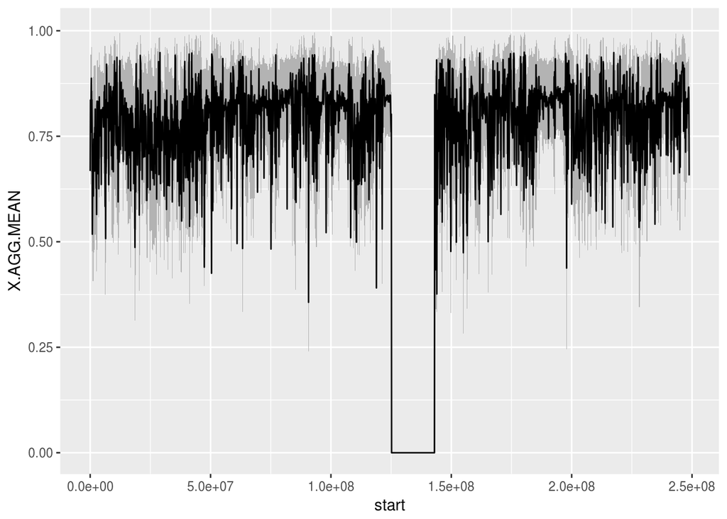

```r
library(ggplot2)
plot_data <- as.data.frame(regions)
plot_data[,grepl("X.", colnames(plot_data))] <-
    apply(plot_data[,grepl("X.", colnames(plot_data))], 2, as.numeric)
AGG.plot <- ggplot(plot_data, aes(start)) +
    geom_ribbon(aes(ymin = X.AGG.MEAN - (X.AGG.SD / 2),
        ymax = X.AGG.MEAN + (X.AGG.SD / 2)), fill = "grey70") +
    geom_line(aes(y = X.AGG.MEAN))
print(AGG.plot)
```

### Flanking regions

We use the `deepblue_select_genes` command to generate a set of genes from the gene model GENCODE v19.

The `deepblue_flank` command derives flanking regions from existing regions. First, we derive regions that start 2500bp before the initially selected regions with a length of 2000bp. Next, we derive the regions that start 1500 base pairs after the initially selected regions with 500 base pairs length. For each region, we consider the DNA strand.

The `deepblue_merge_queries` command merges the region sets defined by two query IDs. Here, we merge the two flanking regions sets we created based on the initially selected genes.

```r
# Select the RP11-34P13 gene locations from gencode v23
q_genes = deepblue_select_genes(
    genes=
        c("RNU6-1100P", "CICP7", "MRPL20", "ANKRD65",
            "HES2", "ACOT7", "HES3", "ICMT"), gene_model="gencode v19")

# Obtain the regions that starts 2500 bases pair before the regions start and
# have 2000 base pairs.
# The 4th argument inform that DeepBlue must consider the region strand
# (column STRAND) to calculate the new region
before_flank_id = deepblue_flank(query_id=q_genes,
     start=-2500, length=2000, use_strand=TRUE)

# Obtain the regions that starts 1500 bases pair after the
# regions end and have 500 base pairs.
# The 4th argument inform that DeepBlue must consider the
# region strand (column STRAND) to calculate the new region
after_flank_id = deepblue_flank(query_id=q_genes,
    start=1500, length=500, use_strand=TRUE)

# Merge both flanking regions set and genes set
flank_merge_id = deepblue_merge_queries(
    query_a_id =before_flank_id, query_b_id=after_flank_id)
all_merge_id = deepblue_merge_queries(
    query_a_id=q_genes, query_b_id=flank_merge_id)

# Request the regions
request_id = deepblue_get_regions(query_id=all_merge_id,
    output_format="CHROMOSOME,START,END,STRAND,@LENGTH")

regions = deepblue_download_request_data(request_id=request_id)
regions
```

```
## GRanges object with 24 ranges and 1 metadata column:
##        seqnames             ranges strand |   @LENGTH
##           <Rle>          <IRanges>  <Rle> | <integer>
##    [1]     chr1   [155784, 156284]      - |       500
##    [2]     chr1   [157784, 157887]      - |       103
##    [3]     chr1   [160387, 162387]      - |      2000
##    [4]     chr1   [327431, 327931]      - |       500
##    [5]     chr1   [329431, 332236]      - |      2805
##    ...      ...                ...    ... .       ...
##   [20]     chr1 [6324329, 6454451]      - |    130122
##   [21]     chr1 [6456951, 6458951]      - |      2000
##   [22]     chr1 [6470478, 6470978]      - |       500
##   [23]     chr1 [6472478, 6484730]      - |     12252
##   [24]     chr1 [6487230, 6489230]      - |      2000
##   -------
##   seqinfo: 1 sequence from an unspecified genome; no seqlengths
```

### Calculated columns

Here, we summarize DNA methylation levels for CpG islands of a specific experiment. Next, we remove those CpG islands for which no values were found using `@AGG.COUNT` > 0.

We use the `@CALCULATED` meta-column to transform the `@AGG.MEAN` value to log scale.

```r
# Select the RP11-34P13 gene locations from gencode v23

# Selecting the data from 2 experiments:
#    GC_T14_10.CPG_methylation_calls.bs_call.GRCh38.20160531.wig
# As we already know the experiments names, we keep all others fields empty.
# We are selecting all regions of chromosome 1
query_id = deepblue_select_experiments(
    experiment="GC_T14_10.CPG_methylation_calls.bs_call.GRCh38.20160531.wig",
    chromosome="chr1")

# Select the CpG Islands annotation from GRCh38
cpg_islands = deepblue_select_annotations(
    annotation="CpG Islands", genome="GRCh38", chromosome="chr1")

# Aggregate
overlapped = deepblue_aggregate(
    data_id=query_id, ranges_id=cpg_islands, column="VALUE")

# Select the aggregated regions that aggregated at least one region from the
# selected experiments (@AGG.COUNT > 0)
filtered = deepblue_filter_regions(query_id=overlapped,
    field="@AGG.COUNT", operation=">", value="0", type="number")

# We remove all regions where the aggregation mean is zero.
filtered_zeros = deepblue_filter_regions(query_id=filtered,
    field="@AGG.MEAN", operation="!=", value="0.0", type="number")

# Retrieve the experiments data (The @NAME meta-column is used to include the
# experiment name and @BIOSOURCE for experiment's biosource
request_id = deepblue_get_regions(query_id=filtered_zeros,
    output_format=
    "CHROMOSOME,START,END,@CALCULATED(return math.log(value_of('@AGG.MEAN'))),@AGG.MEAN,@AGG.COUNT")

regions = deepblue_download_request_data(request_id=request_id)

# We have to perform a manual conversion because the
# package can't know the type for calculated columns
regions$`@CALCULATED(return math.log(value_of('@AGG.MEAN')))` =
    as.numeric(regions$`@CALCULATED(return math.log(value_of('@AGG.MEAN')))`)

head(regions, 5)
```

```
## GRanges object with 5 ranges and 3 metadata columns:
##       seqnames           ranges strand |
##          <Rle>        <IRanges>  <Rle> |
##   [1]     chr1 [ 28735,  29737]      * |
##   [2]     chr1 [135124, 135563]      * |
##   [3]     chr1 [368792, 370063]      * |
##   [4]     chr1 [381172, 382185]      * |
##   [5]     chr1 [491107, 491546]      * |
##       @CALCULATED(return math.log(value_of('@AGG.MEAN'))) @AGG.MEAN
##                                                 <numeric> <numeric>
##   [1]                                           -7.600902     5e-04
##   [2]                                           -0.083708    0.9197
##   [3]                                                   0         1
##   [4]                                            -0.04343    0.9575
##   [5]                                           -0.046044     0.955
##       @AGG.COUNT
##        <integer>
##   [1]         64
##   [2]         30
##   [3]          2
##   [4]         12
##   [5]         21
##   -------
##   seqinfo: 1 sequence from an unspecified genome; no seqlengths
```

### Score matrix

Here, we select a small number of experiments for which we want to build a score matrix based on the column `VALUE`.

We use CpG islands as aggregated regions boundaries.

The `deepblue_score_matrix` command expects a named list with the experiments names and columns that will be used for aggregation, the regions’ boundaries, and the operation that will be performed (min, max, mean, var, sd, median, count).

The `deepblue_score_matrix` command is executed asynchronously. The command `download_request_data` will return a matrix in which the first three columns correspond to the chromosome, start position and end position. The remaining columns will carry the names of the experiments and hold the corresponding aggregated values.

```r
experiments =
    c("GC_T14_10.CPG_methylation_calls.bs_call.GRCh38.20160531.wig",
        "C003N351.CPG_methylation_calls.bs_call.GRCh38.20160531.wig",
        "C005VG51.CPG_methylation_calls.bs_call.GRCh38.20160531.wig",
        "S002R551.CPG_methylation_calls.bs_call.GRCh38.20160531.wig",
        "NBC_NC11_41.CPG_methylation_calls.bs_call.GRCh38.20160531.wig",
        "bmPCs-V156.CPG_methylation_calls.bs_call.GRCh38.20160531.wig",
        "S00BS451.CPG_methylation_calls.bs_call.GRCh38.20160531.wig",
        "S00D1DA1.CPG_methylation_calls.bs_call.GRCh38.20160531.wig",
        "S00D39A1.CPG_methylation_calls.bs_call.GRCh38.20160531.wig")

experiments_columns = list()
for (experiment_name in experiments) {
    experiments_columns[[experiment_name]] = "VALUE"
}

cpgs = deepblue_select_annotations(
    annotation_name="Cpg Islands",
    chromosome="chr22", start=0, end=18000000, genome="GRCh38")

request_id = deepblue_score_matrix(
    experiments_columns=experiments_columns,
    aggregation_function="mean", aggregation_regions_id=cpgs)

score_matrix = deepblue_download_request_data(request_id=request_id)
head(score_matrix, 5)
```

```
##    CHROMOSOME    START      END
## 1:      chr22 10525486 10527570
## 2:      chr22 10571557 10572827
## 3:      chr22 10698820 10699961
## 4:      chr22 10741251 10742442
## 5:      chr22 10961033 10961845
##    C003N351.CPG_methylation_calls.bs_call.GRCh38.20160531.wig
## 1:                                                         NA
## 2:                                                         NA
## 3:                                                         NA
## 4:                                                   0.846770
## 5:                                                   0.806492
##    C005VG51.CPG_methylation_calls.bs_call.GRCh38.20160531.wig
## 1:                                                         NA
## 2:                                                         NA
```

[output cut: 45 more lines]

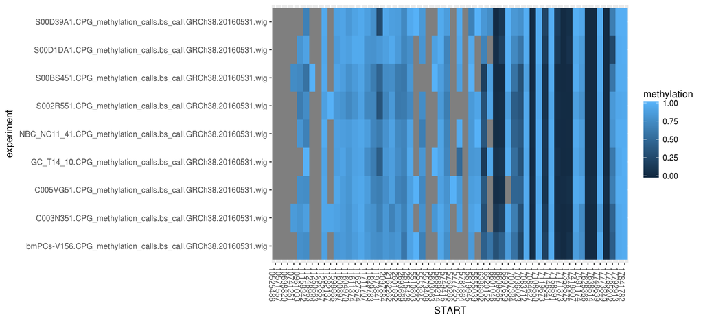

```r
library(ggplot2)
score_matrix_plot = tidyr::gather(score_matrix,
    "experiment", "methylation", -CHROMOSOME, -START, -END)
score_matrix_plot$START <- as.factor(score_matrix_plot$START)
ggplot(score_matrix_plot, aes(x=START, y=experiment, fill=methylation)) +
    geom_tile() +
    theme(axis.text.x=element_text(angle=-90))
```

### Data Export

DeepBlueR allows you to conveniently save results to disk. Any result can be saved as tab delimited file using `deepblue_export_tab`. For example, we can save the score matrix generated in the above example:

```r
deepblue_export_tab(score_matrix, file.name = "my_score_matrix")
```

Results obtained with `deepblue_get_regions` are of type GenomicRanges and can be exported as tab delimited files preserving all columns or as BED files, where a specific column can optionally be selected to populate the ‘score’ column of the BED file. To demonstrate this, we use the result from the tiling regions example further above:

```r
request_id = deepblue_get_regions(query_id=overlapped,
    output_format="CHROMOSOME,START,END,@AGG.MEAN,@AGG.SD")

regions = deepblue_download_request_data(request_id=request_id)
deepblue_export_bed(regions,
                    file.name = "my_tiling_regions",
                    score.field = "@AGG.MEAN")
```

Furthermore, metadata associated with any id can be stored locally using the `deepblue_export_meta_data` command. To this end, we first obtain the experiment id of the file we used in the tiling regions example.

```r
exp_id <- deepblue_name_to_id(
    "GC_T14_10.CPG_methylation_calls.bs_call.GRCh38.20160531.wig",
    collection = "experiments")$id

deepblue_export_meta_data(exp_id, file.name = "GC_T14")
```

This command can also handle lists of ids, for instance:

```r
deepblue_export_meta_data(list("e30035", "e30036"),
file.name = "test_export")
```

In some cases, users will perform a series of requests. We provide the command `deepblue_batch_export` to save these results and their associated metadata to disk in one go. This method will save each file as it becomes available, i.e. it will be saved once the request is successfully processed by DeepBlue:

```r
experiments = deepblue_list_experiments(type="peaks", epigenetic_mark="H3K4me3",
    biosource=c("inflammatory macrophage", "macrophage"),
    project="BLUEPRINT Epigenome")
experiment_names = deepblue_extract_names(experiments)

request_ids = foreach(experiment = experiment_names) %do%{
  query_id = deepblue_select_experiments(experiment_name = experiment,
                                        chromosome = "chr21")

  request_id = deepblue_get_regions(query_id =query_id,
    output_format = "CHROMOSOME,START,END")
}
request_data = deepblue_batch_export_results(request_ids,
                             target.directory = "BLUEPRINT macrophages chr21")
```

## Options

DeepBlueR comes with default options that can be changed by the user. To list the current options use the following command:

```r
deepblue_options()
```

```
## $url
## [1] "http://deepblue.mpi-inf.mpg.de/xmlrpc"
##
## $user_key
## [1] "anonymous_key"
##
## $do_not_cache
## [1] FALSE
##
## $force_download
## [1] FALSE
##
## $debug
## [1] FALSE
```

- `url` This is the URL of the DeepBlue application server and should not be changed
- `user_key` This option can be replaced by the personal key of the user after successful registration at http://deepblue.mpi-inf.mpg.de. The key can be found by logging into the web application and clicking on the user name in the top left corner. Registered users have access to advanced features of DeepBlue, e.g. they can review previous requests.
- `do_not_cache` Allows users to switch off the caching functionality of DeepBlueR. See Caching.
- `force_download` If the users wishes to overwrite cached results for the following requests, this option can be switched on. See Caching.
- `debug` Switching on this option enables verbose output only useful for debugging.

Changing an option works as follows:

```r
deepblue_options(do_not_cache = TRUE)
```

Another example (replace ‘my_user_key’ with the actual key):

```r
deepblue_options(user_key = "my_user_key")
```

In case you wish to restore the default options simply call

```r
deepblue_reset_options()
```

## Caching

DeepBlueR by default creates a file ‘DeepBlueR.cache’ in the current working directory. Downloaded results / regions are stored there and can be instantly retrieved, which is particularly useful for users with limited network bandwith. However, in case caching is not desired it can be switched off (see Options)

To check the status of the cache you can use the following command:

```r
deepblue_cache_status()
```

This will report the cache size and the number of requests currently stored. Alternatively, users can list the request ids for which results are available:

```r
deepblue_list_cached_requests()
```

Over time, the cache can quickly grow in size. It is possible to remove individual requests from the cache if the request id is known:

```r
deepblue_delete_request_from_cache("r123")
```

In most cases it will be simpler to simply delete the cache:

```r
deepblue_clear_cache()
```